# Causal inference approach aimed to hybrid control arm design

Author

David Herman

Published

March 27, 2026

# 1 Introduction

This turorial was created with the aim of simulating and applying different weightening/balancing strategies to the Hybrid Control Arm (HCA) study using retrospective RWD to augment the internal control arm of the trial that has the standard treatment.

The trial objective is to compare the interventional drug (Treatment arm) against a reconstructed hybrid arm. This hybrid arm integrates the prospectively randomized patients (internal controls with standard treatment) with an external control RWD patients treated with standard treatment.

By supplementing the internal control with historical RWD, we aim to perform a matched/weighted based study to perform comparative study between patients under the interventional drug and the reconstructed hybrid arm (standard care).

This tutorial implemented the method explained by Majumdmar et al 2022: Design of a Confirmatory trial with a Hybrid Randomized and External Control Arm. At the end, unmeasured confounding methods were also applied given the context for an internal project at my placework.

# 2 Objective

To assess the comparable efficacy of the interventional drug (“treatment drug”) to the hybrid arm (“standard care drug”) among the patients with a type of hematologic rare disease. Efficacy will be assed as CR+PR by 4 months according to IWG 2006 criteria.

# 3 Data source

Simulated data set using RTC sample size (treatment arm and control/standard care) and RWD expected:

- Trial: data from 48 patients (R 2:1, TREATMENT_DRUG:32 and STANDARD_DRUG:16)
- External Data (from EHR): retrospective data from 18 patients with patients with a type of hematologic rare disease treated with STANDARD_DRUG and have comparable eligibility criteria to the trial.

To keep the adjustment strategy transparent, we retain a reduced confounder set compared to the original study:

- `treat_drug`: YES = 1, NO = 0 (binary variable “A”)
- `cr_pr_4m`: CR+PR by 4 months according to IWG 2006 criteria (binary variable “Y”)
- `age`: age in years
- `sex`: sex (1 = male)
- `race`: categorical variable
- `bmi`: categorical variable
- `ECOG`: categorical variable

```r
library(causaldata) # Provides datasets used in causal inference, including the NHEFS
library(tidyverse) # Core data science workflow
library(ggdag) # Visualization tools for directed acyclic graphs (DAGs)
library(broom) # Converts model objects (e.g., lm, glm) into tidy df.
library(dagitty) # Formal specification and analysis of causal DAGs
library(MatchIt) # Implements propensity score matching algorithms
library(WeightIt) # Implements propensity score weighting and balancing approaches
library(cobalt) # Covariate balance diagnostics and visualization
library(ggplot2) # Grammar of graphics plotting system
library(glmnet) # LASSO log regression (appendix)
library(patchwork) # combined plots
library(rsample)
library(lmtest)
library(plm)
library(EValue) # e-value method for unmeasured confounding
library(tipr) # for tipping point analysis for unmeasured confounding
```

```r
set.seed(20260310)

# -----------------------------
# 1. Helper functions
# -----------------------------

rbern <- function(n, p) rbinom(n, size = 1, prob = p)

# Simulate baseline covariates
sim_covariates <- function(n, source = c("trial", "rwd")) {
  source <- match.arg(source)

  if (source == "trial") {
    tibble(
      age = round(rnorm(n, mean = 73, sd = 7)),
      sex = rbern(n, 0.62), # 1 = male
      race = sample(
        c("White", "Other"),
        size = n,
        replace = TRUE,
        prob = c(0.70, 0.3)
      ),
      bmi = sample(
        c("<25", "25-30", ">=30"),
        size = n,
        replace = TRUE,
        prob = c(0.30, 0.45, 0.25)
      ),
      ECOG = sample(
        c("0", ">1"),
        size = n,
        replace = TRUE,
        prob = c(0.25, 0.75)
      )
    )
  } else {
    # External RWD made slightly older / less fit on average
    tibble(
      age = round(rnorm(n, mean = 75, sd = 8)),
      sex = rbern(n, 0.68),
      race = sample(
        c("White", "Other"),
        size = n,
        replace = TRUE,
        prob = c(0.72, 0.28)
      ),
      bmi = sample(
        c("<25", "25-30", ">=30"),
        size = n,
        replace = TRUE,
        prob = c(0.36, 0.42, 0.22)
      ),
      ECOG = sample(
        c("0", ">1"),
        size = n,
        replace = TRUE,
        prob = c(0.18, 0.62)
      )
    )
  }
}

# Baseline NO response probability
# Keep this simple and interpretable
get_p_aza <- function(age, sex, race, bmi, ECOG) {
  p <- 0.30 +
    ifelse(age < 70, 0.05, 0) +
    ifelse(age >= 80, -0.05, 0) +
    ifelse(sex == 1, -0.02, 0) +
    ifelse(race == "White", 0.03, 0) +
    ifelse(race == "Other", -0.02, 0) +
    ifelse(bmi == "25-30", 0.03, 0) +
    ifelse(bmi == ">=30", -0.03, 0) +
    ifelse(ECOG == "0", -0.05, 0) +
    ifelse(ECOG == ">1", -0.12, 0)

  pmin(pmax(p, 0.05), 0.80)
}

# -----------------------------
# 2. Trial data
# -----------------------------

n_trial <- 48
n_ivo <- 32
n_aza <- 16

trial_cov <- sim_covariates(n_trial, source = "trial")

df_trial <- trial_cov %>%
  mutate(
    patient_id = paste0("TRIAL_", sprintf("%03d", 1:n_trial)),
    source = "trial",
    treat_drug = c(rep(1, n_ivo), rep(0, n_aza)), # 1 = YES, 0 = NO
    p_aza = get_p_aza(age, sex, race, bmi, ECOG),
    # drug effect estimated to be +30 percentage points over standard treatment (NO)
    p_response = ifelse(treat_drug == 1, pmin(p_aza + 0.30, 0.95), p_aza),
    cr_pr_4m = rbern(n_trial, p_response)
  ) %>%
  dplyr::select(
    patient_id,
    source,
    treat_drug,
    cr_pr_4m,
    age,
    sex,
    race,
    bmi,
    ECOG
  )

# -----------------------------
# 3. External RWD data
# -----------------------------

n_rwd <- 18

rwd_cov <- sim_covariates(n_rwd, source = "rwd")

df_rwd <- rwd_cov %>%
  mutate(
    patient_id = paste0("RWD_", sprintf("%03d", 1:n_rwd)),
    source = "rwd",
    treat_drug = 0, # all external patients are NO
    p_aza = get_p_aza(age, sex, race, bmi, ECOG),
    p_response = p_aza,
    cr_pr_4m = rbern(n_rwd, p_response)
  ) %>%
  dplyr::select(
    patient_id,
    source,
    treat_drug,
    cr_pr_4m,
    age,
    sex,
    race,
    bmi,
    ECOG
  )

# -----------------------------
# 4. Optional combined dataset
# -----------------------------

df_all <- bind_rows(df_trial, df_rwd) %>%
  mutate(
    treat_drug = factor(treat_drug, levels = c(0, 1), labels = c("NO", "YES")),
    sex = factor(sex, levels = c(0, 1), labels = c("Female", "Male")),
    source = factor(source, levels = c("trial", "rwd")),
    ECOG = factor(ECOG, levels = c("0", ">1")),
    bmi = factor(bmi, levels = c("<25", "25-30", ">=30")),
    race = factor(race)
  )

# -----------------------------
# 5. Quick checks
# -----------------------------

table(df_trial$treat_drug)
```

```
 0  1
16 32
```

```r
table(df_rwd$treat_drug)
```

```
 0
18
```

```r
df_trial %>%
  count(treat_drug, cr_pr_4m)
```

```
# A tibble: 4 × 3
  treat_drug cr_pr_4m     n
       <dbl>    <int> <int>
1          0        0    14
2          0        1     2
3          1        0    14
4          1        1    18
```

```r
df_rwd %>%
  count(cr_pr_4m)
```

```
# A tibble: 2 × 2
  cr_pr_4m     n
     <int> <int>
1        0    15
2        1     3
```

```r
df_all %>%
  group_by(source, treat_drug) %>%
  summarise(
    n = n(),
    resp_rate = mean(cr_pr_4m),
    mean_age = mean(age),
    .groups = "drop"
  )
```

```
# A tibble: 3 × 5
  source treat_drug     n resp_rate mean_age
  <fct>  <fct>      <int>     <dbl>    <dbl>
1 trial  NO            16     0.125     69.4
2 trial  YES           32     0.562     72.5
3 rwd    NO            18     0.167     71.3
```

```r
head(df_trial)
```

```
# A tibble: 6 × 9
  patient_id source treat_drug cr_pr_4m   age   sex race  bmi   ECOG
  <chr>      <chr>       <dbl>    <int> <dbl> <int> <chr> <chr> <chr>
1 TRIAL_001  trial           1        0    67     1 White <25   >1
2 TRIAL_002  trial           1        0    72     0 Other >=30  >1
3 TRIAL_003  trial           1        1    71     1 White <25   >1
4 TRIAL_004  trial           1        0    70     1 White 25-30 0
5 TRIAL_005  trial           1        1    72     0 White <25   0
6 TRIAL_006  trial           1        0    65     0 Other 25-30 0
```

```r
head(df_rwd)
```

```
# A tibble: 6 × 9
  patient_id source treat_drug cr_pr_4m   age   sex race  bmi   ECOG
  <chr>      <chr>       <dbl>    <int> <dbl> <int> <chr> <chr> <chr>
1 RWD_001    rwd             0        0    66     1 White 25-30 >1
2 RWD_002    rwd             0        0    74     1 Other 25-30 0
3 RWD_003    rwd             0        0    75     1 White >=30  >1
4 RWD_004    rwd             0        0    70     1 Other <25   >1
5 RWD_005    rwd             0        0    61     0 White 25-30 >1
6 RWD_006    rwd             0        1    63     0 White 25-30 >1
```

```r
df_all <- df_all %>%
  mutate(
    A = ifelse(treat_drug == "YES", 1, 0),
    Y = cr_pr_4m,
    in_trial = ifelse(source == "trial", 1, 0)
  ) %>%
  mutate(
    treat_drug = factor(treat_drug, levels = c("NO", "YES"))
  )

head(df_all)
```

```
# A tibble: 6 × 12
  patient_id source treat_drug cr_pr_4m   age sex    race  bmi   ECOG      A
  <chr>      <fct>  <fct>         <int> <dbl> <fct>  <fct> <fct> <fct> <dbl>
1 TRIAL_001  trial  YES               0    67 Male   White <25   >1        1
2 TRIAL_002  trial  YES               0    72 Female Other >=30  >1        1
3 TRIAL_003  trial  YES               1    71 Male   White <25   >1        1
4 TRIAL_004  trial  YES               0    70 Male   White 25-30 0         1
5 TRIAL_005  trial  YES               1    72 Female White <25   0         1
6 TRIAL_006  trial  YES               0    65 Female Other 25-30 0         1
# ℹ 2 more variables: Y <int>, in_trial <dbl>
```

# 4 Target Estimand and Identification

The objective is to estimate the Average Treatment Effect in the Treated (ATT) of the new interventional drug on the response rate (CR+PR) at 4 months, defined as the mean difference in potential outcomes among patients who received the new drug:

E[Y(1)−Y(0)∣A=1]

where:

- A = Treatment (`treat_drug`)
- Y = CR+PR by 4 months (`cr_pr_4m`)

Under the assumed causal structure, baseline covariates that affect both treatment assignment and outcome constitute the backdoor adjustment set:

Z = {age, sex, race, bmi, ECOG}

Conditioning on Z aims to block confounding pathways between treatment and outcome. Under the assumptions of conditional exchangeability, positivity, and consistency, the ATT can be identified from the observed data using weighting or outcome regression methods.

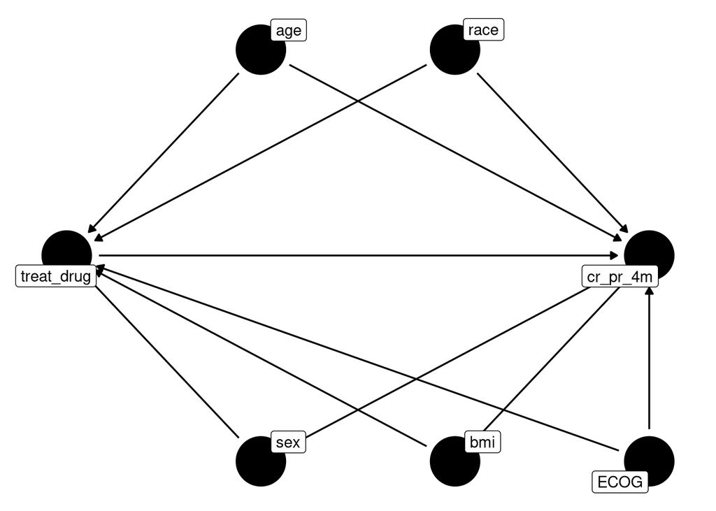

Figure 1: DAG structure

```r
dag <- dagitty(
  "
dag {

  treat_drug [pos=\"0,0\"]
  cr_pr_4m [pos=\"3,0\"]

  age [pos=\"1,1\"]
  sex [pos=\"1,-1\"]
  race [pos=\"2,1\"]
  bmi [pos=\"2,-1\"]
  ECOG [pos=\"3,-1\"]

  treat_drug -> cr_pr_4m

  age -> cr_pr_4m
  age -> treat_drug
  sex -> cr_pr_4m
  sex -> treat_drug
  race -> cr_pr_4m
  race -> treat_drug
  bmi -> cr_pr_4m
  bmi -> treat_drug
  ECOG -> cr_pr_4m
  ECOG -> treat_drug
}
"
)

ggdag(dag, text = FALSE, use_labels = "name") +
  theme_dag()
```

Identification of the ATT relies on the following assumptions: